This is the next level of analysis for the celltraq data. In this analysis, we will be looking at the continuous drop in conductance feature extraction. The feature we will be looking at is where the conductance drops with respect to a certain date and then in the subsequent dates the new values start from the point it has dropped to.

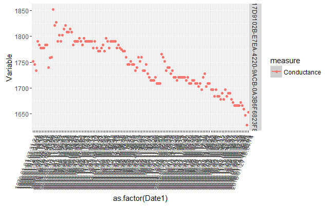

```r
# Take one sample data
Temp_bat_consol <- bat_newfeat4 %>% filter(Battery %in% list2_1000[8]) %>% filter(measure=="Conductance")
# Some visualisation
q5 <- ggplot(data=Temp_bat_consol,aes(as.factor(Date1),Variable,color=measure)) + geom_point() + facet_grid(Battery~.,scales = "free") + geom_smooth(method="lm") # ,margins =TRUE can be included if we want everything together in one graph #measure~
q5 + theme(axis.text.x=element_text(angle=70,hjust=1))
```

We need to take a chunk of data corresponding to each date and look at the drop in conductance. Let us look at each unique date formats and do the same method we used for extracting the features for conductance

[figure not shown]

For doing the new features for conductance, the old method of finding the slopes for a period of 6 months dosent work. What needs to be done is the following 1. Find the difference between a preceeding conductance reading and the following one. 2. If the follwing one is a drop, then look at the quantum of drop. 3. Do a threshold drop to say around a value more than the mean drop 4. Find the date of the following reading which resulted in the large drop. 5. First check that no values before that date is lower than this dropped value. 6. The secon check which needs to be done is to check that no value after the taken date is also not above this dropped value 7. Continue this process of checking for large drops and scanning the values above and below the date where the large drop has happened. 8. Introduce some measure of aggregating the large dropped values